# SXH

Author

Hoang Quoc Cuong

Published

January 27, 2026

# 1 **DỮ LIỆU SXH**

Báo cáo được cập nhập vào lúc **2026-01-27 21:51:29 | Dữ liệu SXH 2026**

Bản đồ Cần Thơ (thông tin chi tiết phường, xã mới) [**click here**](https://tuhocr.github.io/canthosxh/mapcantho.html)

**Để copy file ảnh đồ thị full-size, ta right-click lên hình, chọn `Open image in new tab`**

# 2 **KIỂM TRA DỮ LIỆU**

**Nhập dữ liệu sai lệch năm (vd file 2025 nhưng lại có bệnh nhân của năm 2026)**

**`Dữ liệu nhập lệch năm`**

```
Dữ liệu ban đầu: 472
Dữ liệu sau khi lọc theo năm: 472
Dữ liệu nhập lệch năm: 0
```

**Nếu tổng số `TTYTKV` không vượt quá 22 (năm 2025) hay 20 (năm 2026) thì dữ liệu chính xác.**

**Tổng số TTYTKV là 20**

**`TTYTKV`**

```
    TTYT KV Bình Thủy      TTYT KV Cái Răng  TTYT KV Châu Thành A TTYT KV Châu Thành HG   TTYT KV Cù Lao Dung       TTYT KV Kế Sách
                  156                    62                    21                    27                     2                    12
      TTYT KV Long Mỹ      TTYT KV Long Phú         TTYT KV Mỹ Tú      TTYT KV Mỹ Xuyên       TTYT KV Ngã Năm         TTYT KV Ô Môn
                    7                    20                     5                     1                     1                    30
   TTYT KV Phụng Hiệp     TTYT KV Sóc Trăng     TTYT KV Thạnh Trị      TTYT KV Thới Lai      TTYT KV Thốt Nốt       TTYT KV Vị Thủy
                   27                    44                     1                    27                    10                     7
    TTYT KV Vĩnh Châu    TTYT KV Vĩnh Thạnh
                    7                     5
Tổng số TTYTKV là 20
```

**Nếu tổng số `PHUONG_XA_MOI` không vượt quá 103 thì dữ liệu chính xác.**

**Tổng số PHUONG_XA_MOI là 79**

**`PHUONG_XA_MOI`**

```
        An Bình     An Lạc Thôn         An Ninh       Bình Thủy         Cái Khế        Cái Răng      Châu Thành           Cờ Đỏ
             17               5               9              44               6              30              14               3
    Cù Lao Dung         Đại Hải       Đại Thành       Đông Hiệp      Đông Phước      Đông Thuận       Hiệp Hưng     Hồ Đắc Kiện
              2               3               6               5               6               1               2               3
         Hòa An        Hưng Phú         Kế Sách       Khánh Hòa Lịch Hội Thượng         Liêu Tú       Long Hưng         Long Mỹ
              2              15               3               2               3               3               4               3
       Long Phú      Long Phú 1      Long Tuyền         Mỹ Quới           Mỹ Tú        Mỹ Xuyên         Ngã Bảy         Ngọc Tố
              2               1              19               1               1               5               7               1
        Nhơn Ái         Nhơn Mỹ       Ninh Kiều           Ô Môn      Phong Điền         Phú Hữu         Phú Lợi         Phú Tâm
              4               1              21              11               8               7               4               6
     Phụng Hiệp      Phước Thới     Phương Bình       Sóc Trăng         Tài Văn          Tân An        Tân Bình         Tân Hòa
              1              12               1              14               1              34               1              11
        Tân Lộc       Tân Thạnh       Thạnh Hòa   Thạnh Thới An      Thạnh Xuân    Thới An Đông       Thới Hưng        Thới Lai
              3               1               7               1               7              15               2               4
      Thới Long        Thốt Nốt       Thuận Hòa      Thuận Hưng         Trần Đề      Trung Hưng      Trung Nhứt    Trường Khánh
              7               4               3               1               7               5               2               2
    Trường Long Trường Long Tây    Trường Thành     Trường Xuân          Vị Tân        Vị Thanh      Vị Thanh 1        Vĩnh Hải
              5               3               2               5               2               3               1               2
       Vĩnh Lợi      Vĩnh Phước      Vĩnh Thạnh      Vĩnh Trinh      Vĩnh Tường       Vĩnh Viễn        Xà Phiên
              1               3               2               3               1               2               1
Tổng số PHUONG_XA_MOI là 79
```

**Nếu kết quả tổng số ca theo `TTYTKV` và `PHUONG_XA_MOI` không vượt quá 103 thì dữ liệu chính xác.**

Số liệu này thể hiện bao nhiều phường xã có ca bệnh tương ứng với trung tâm y tế khu vực, tổng số không vượt qua 103 phường xã. Cần kiểm tra xem 1 phường xã có bị trùng ở các trung tâm y tế khu vực khác nhau không.

**Dữ liệu bị trùng**

```
        An Bình     An Lạc Thôn         An Ninh       Bình Thủy         Cái Khế        Cái Răng      Châu Thành           Cờ Đỏ
              1               1               1               1               1               1               1               1
    Cù Lao Dung         Đại Hải       Đại Thành       Đông Hiệp      Đông Phước      Đông Thuận       Hiệp Hưng     Hồ Đắc Kiện
              1               1               1               1               1               1               1               1
         Hòa An        Hưng Phú         Kế Sách       Khánh Hòa Lịch Hội Thượng         Liêu Tú       Long Hưng         Long Mỹ
              1               1               1               1               1               1               1               1
       Long Phú      Long Phú 1      Long Tuyền         Mỹ Quới           Mỹ Tú        Mỹ Xuyên         Ngã Bảy         Ngọc Tố
              1               1               1               1               1               1               1               1
        Nhơn Ái         Nhơn Mỹ       Ninh Kiều           Ô Môn      Phong Điền         Phú Hữu         Phú Lợi         Phú Tâm
              1               1               1               1               1               1               1               1
     Phụng Hiệp      Phước Thới     Phương Bình       Sóc Trăng         Tài Văn          Tân An        Tân Bình         Tân Hòa
              1               1               1               1               1               1               1               1
        Tân Lộc       Tân Thạnh       Thạnh Hòa   Thạnh Thới An      Thạnh Xuân    Thới An Đông       Thới Hưng        Thới Lai
              1               1               1               1               1               1               1               1
      Thới Long        Thốt Nốt       Thuận Hòa      Thuận Hưng         Trần Đề      Trung Hưng      Trung Nhứt    Trường Khánh
              1               1               1               1               1               1               1               1
    Trường Long Trường Long Tây    Trường Thành     Trường Xuân          Vị Tân        Vị Thanh      Vị Thanh 1        Vĩnh Hải
              1               1               1               1               1               1               1               1
       Vĩnh Lợi      Vĩnh Phước      Vĩnh Thạnh      Vĩnh Trinh      Vĩnh Tường       Vĩnh Viễn        Xà Phiên
              1               1               1               1               1               1               1
Tổng số PHUONG_XA_MOI là 79
[1] TTYTKV        PHUONG_XA_MOI TONG_SO_CA
<0 rows> (or 0-length row.names)
```

# 3 **SỐ CA THEO NGÀY [DỮ LIỆU GỐC]**

| TTYTKV | PHUONG_XA_MOI | NGAY_VV | TUOI | PHAN_DO | GHI_CHU | NGUOI_NHAP_LIEU |
| --- | --- | --- | --- | --- | --- | --- |
| TTYT KV Cái Răng | Cái Răng | 2026-01-01 | 25 | A97.0 | BV Đại học Nam Cần Thơ | CDC Cần Thơ |
| TTYT KV Thới Lai | Thới Lai | 2026-01-01 | 2 | A97.0 | BVNĐ Cần Thơ | CDC Cần Thơ |
| TTYT KV Bình Thủy | Bình Thủy | 2026-01-02 | 34 | A97.0 | BVĐK Tâm Minh Đức | CDC Cần Thơ |
| TTYT KV Bình Thủy | Thới An Đông | 2026-01-04 | 7 | A97.0 | BVNĐ Cần Thơ | CDC Cần Thơ |
| TTYT KV Bình Thủy | Thới An Đông | 2026-01-03 | 15 | A97.0 | BVNĐ Cần Thơ | CDC Cần Thơ |
| TTYT KV Cái Răng | Cái Răng | 2026-01-03 | 19 | A97.0 | BVĐK TƯ | CDC Cần Thơ |
| TTYT KV Cái Răng | Cái Răng | 2026-01-04 | 33 | A97.0 | BV Hòa Hảo - Medic Cần Thơ | CDC Cần Thơ |
| TTYT KV Bình Thủy | Tân An | 2026-01-04 | 9 | A97.0 | BVNĐ Cần Thơ | CDC Cần Thơ |
| TTYT KV Bình Thủy | Tân An | 2026-01-04 | 16 | A97.0 | BVNĐ Cần Thơ | CDC Cần Thơ |
| TTYT KV Bình Thủy | Tân An | 2026-01-02 | 19 | A97.0 | BV Tim Mạch | CDC Cần Thơ |

[output cut: 462 more lines]

# 4 **TỔNG SỐ CA TRONG NĂM THEO KHU VỰC**

**Từ ngày 2026-01-01 đến ngày 2026-01-22**

**Tổng số ca: 472 | Tổng số TTYT KV: 20 | Tổng số phường, xã: 103**

**Tổng số phường, xã có ca SXH: 79**

**Tổng số phường, xã có KHÔNG có SXH: 24 (An Thạnh, Đại Ngãi, Gia Hòa, Hỏa Lựu, Hòa Tú, Lai Hòa, Lâm Tân, Long Bình, Lương Tâm, Mỹ Hương, Mỹ Phước, Ngã Năm, Nhu Gia, Phong Nẫm, Phú Lộc, Tân Long, Tân Phước Hưng, Thạnh An, Thạnh Phú, Thạnh Quới, Thới An Hội, Vị Thủy, Vĩnh Châu, Vĩnh Thuận Đông)**

| TTYTKV | Phường, xã mới | Tổng số ca |
| --- | --- | --- |
| TTYT KV Bình Thủy | Bình Thủy | 44 |
| TTYT KV Bình Thủy | Tân An | 34 |
| TTYT KV Bình Thủy | Ninh Kiều | 21 |
| TTYT KV Bình Thủy | Long Tuyền | 19 |
| TTYT KV Bình Thủy | An Bình | 17 |
| TTYT KV Bình Thủy | Thới An Đông | 15 |
| TTYT KV Bình Thủy | Cái Khế | 6 |
| TTYT KV Châu Thành A | Tân Hòa | 11 |
| TTYT KV Châu Thành A | Thạnh Xuân | 7 |
| TTYT KV Châu Thành A | Trường Long Tây | 3 |

[output cut: 69 more lines]

# 5 **ĐỒ THỊ TỔNG SỐ CA THEO KHU VỰC**

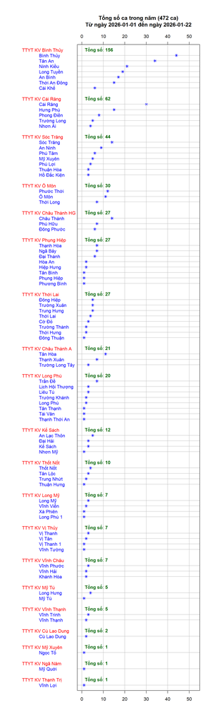

# 6 **TỔNG SỐ CA THEO THÁNG**

| TTYTKV | Phường, xã mới | Tháng | Tổng số ca |
| --- | --- | --- | --- |
| TTYT KV Bình Thủy | An Bình | 1 | 17 |
| TTYT KV Kế Sách | An Lạc Thôn | 1 | 5 |
| TTYT KV Sóc Trăng | An Ninh | 1 | 9 |
| TTYT KV Bình Thủy | Bình Thủy | 1 | 44 |
| TTYT KV Bình Thủy | Cái Khế | 1 | 6 |
| TTYT KV Cái Răng | Cái Răng | 1 | 30 |
| TTYT KV Châu Thành HG | Châu Thành | 1 | 14 |
| TTYT KV Thới Lai | Cờ Đỏ | 1 | 3 |
| TTYT KV Cù Lao Dung | Cù Lao Dung | 1 | 2 |
| TTYT KV Kế Sách | Đại Hải | 1 | 3 |

[output cut: 69 more lines]

# 7 **ĐỒ THỊ TỔNG SỐ CA THEO THỜI GIAN**

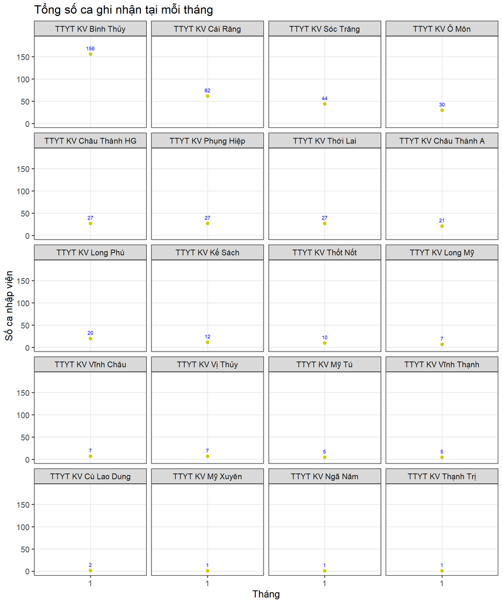

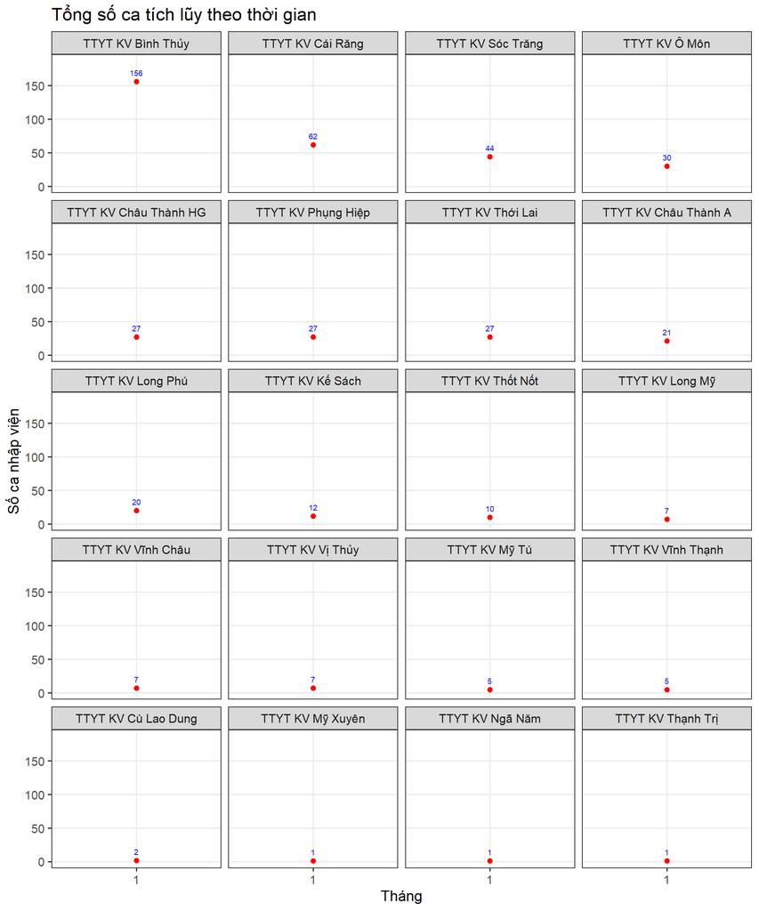

# 8 **TỔNG SỐ CA THEO TUẦN**

| TTYTKV | PHUONG_XA_MOI | WEEK | COUNT |
| --- | --- | --- | --- |
| TTYT KV Bình Thủy | An Bình | 1 | 3 |
| TTYT KV Kế Sách | An Lạc Thôn | 1 | 3 |
| TTYT KV Sóc Trăng | An Ninh | 1 | 1 |
| TTYT KV Bình Thủy | Bình Thủy | 1 | 9 |
| TTYT KV Bình Thủy | Cái Khế | 1 | 1 |
| TTYT KV Cái Răng | Cái Răng | 1 | 7 |
| TTYT KV Châu Thành HG | Châu Thành | 1 | 4 |
| TTYT KV Thới Lai | Cờ Đỏ | 1 | 1 |
| TTYT KV Kế Sách | Đại Hải | 1 | 1 |
| TTYT KV Phụng Hiệp | Đại Thành | 1 | 1 |

[output cut: 161 more lines]

VẼ ĐỒ THỊ

# 9 **ĐỒ THỊ THEO NGÀY**

## 9.1 TTYT KV Cái Răng

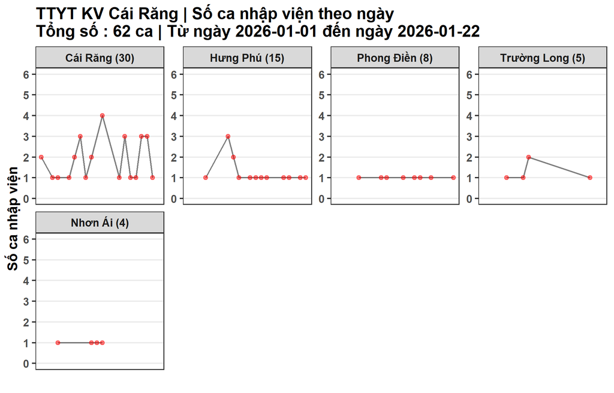

## 9.2 TTYT KV Châu Thành HG

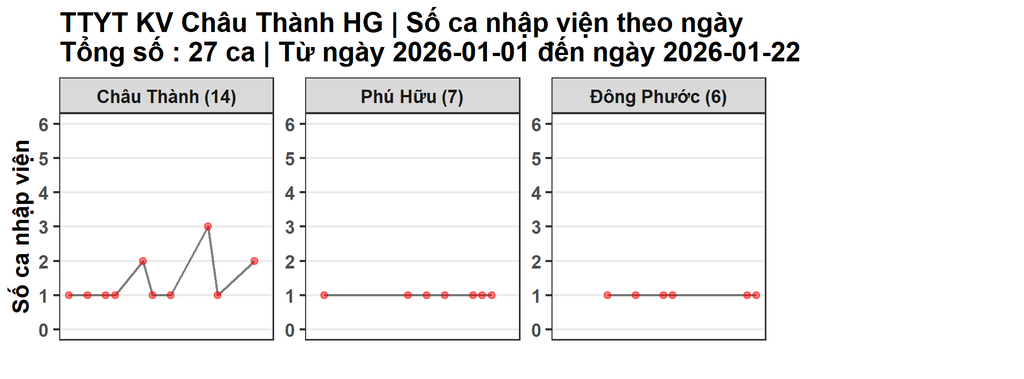

## 9.3 TTYT KV Phụng Hiệp

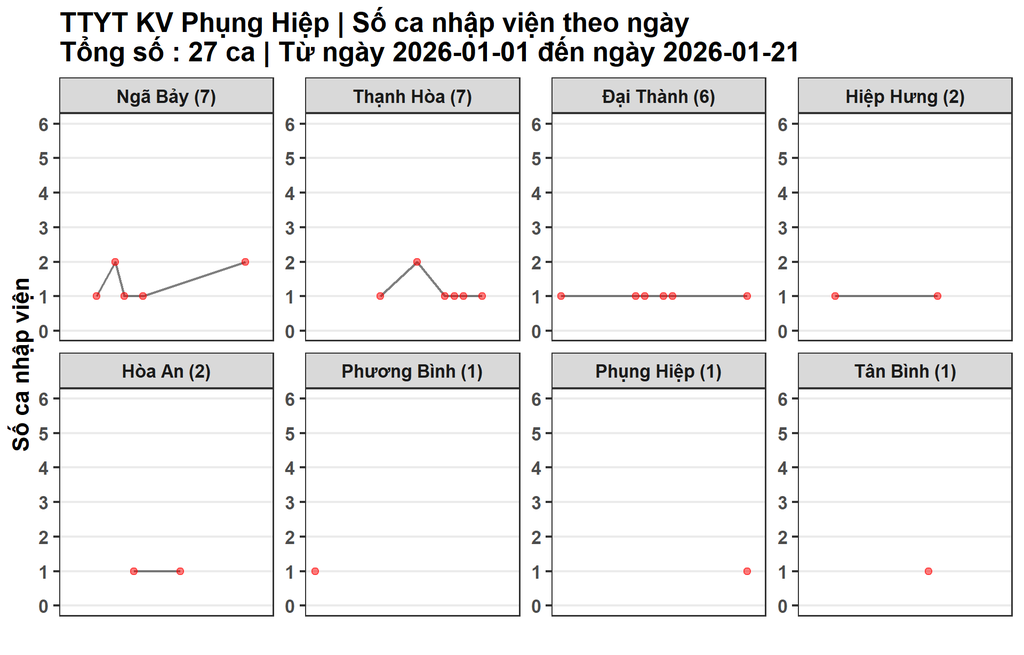

## 9.4 TTYT KV Châu Thành A

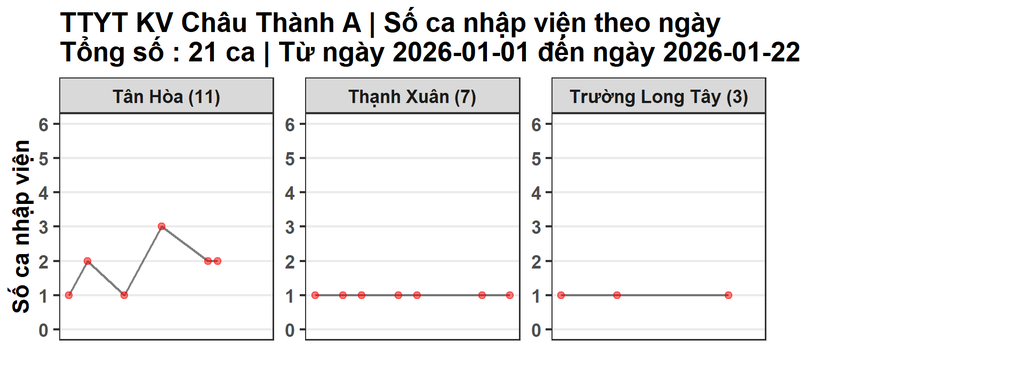

## 9.5 TTYT KV Thới Lai

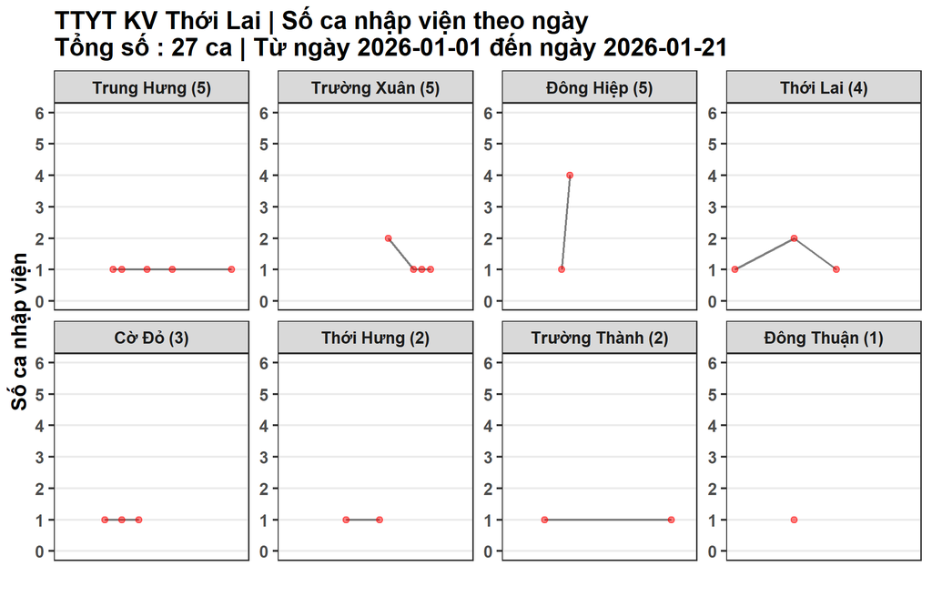

## 9.6 TTYT KV Long Phú

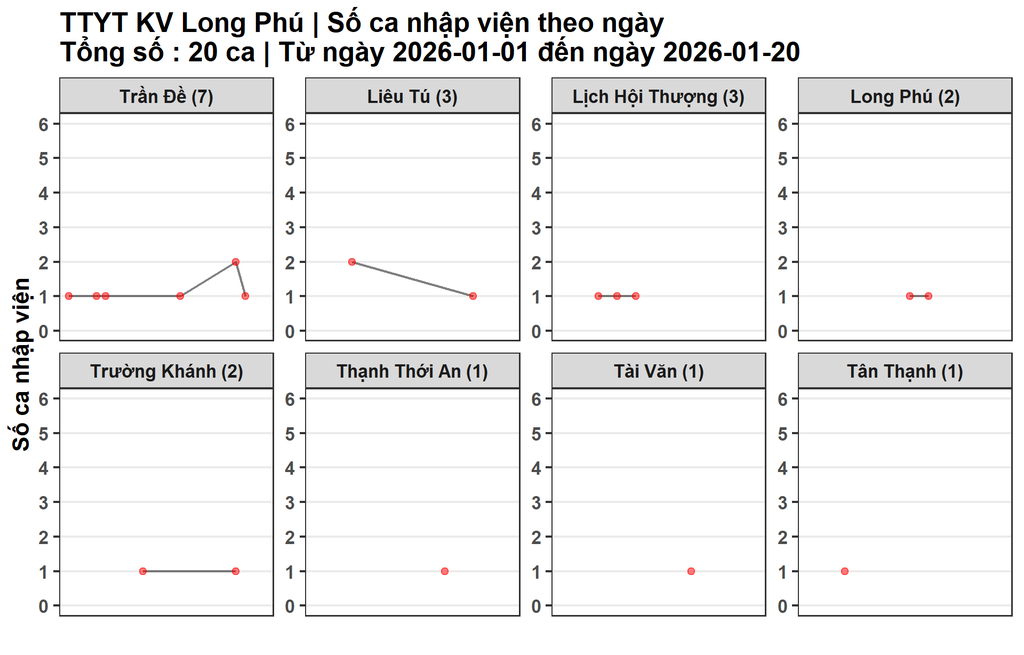

## 9.7 TTYT KV Bình Thủy

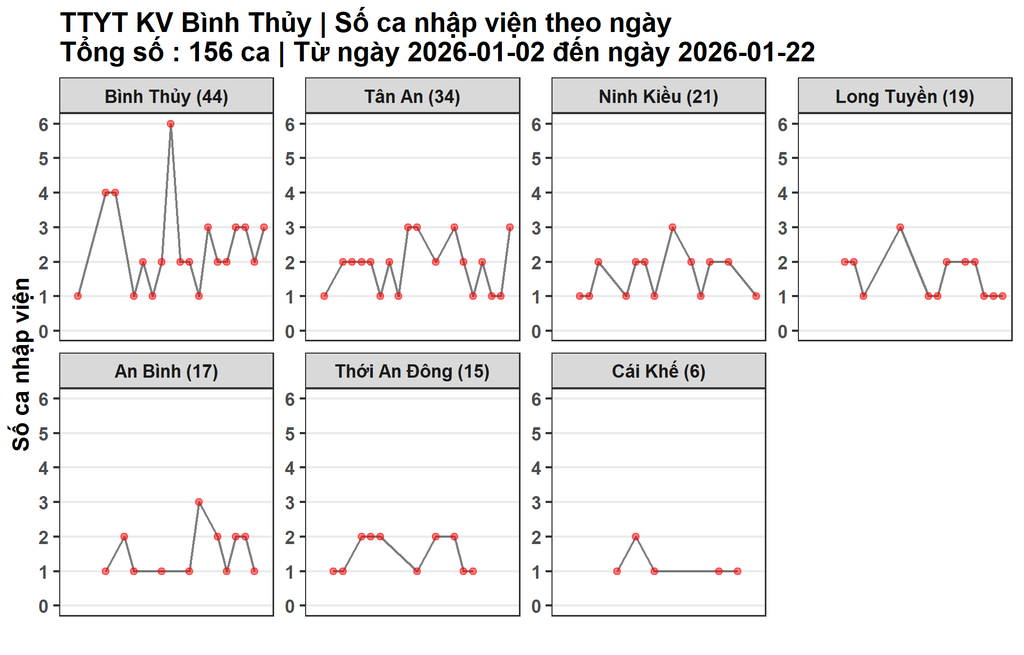

## 9.8 TTYT KV Ô Môn

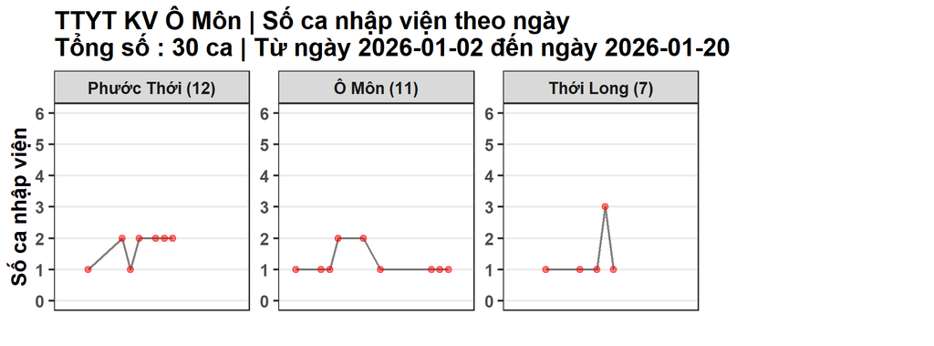

## 9.9 TTYT KV Sóc Trăng

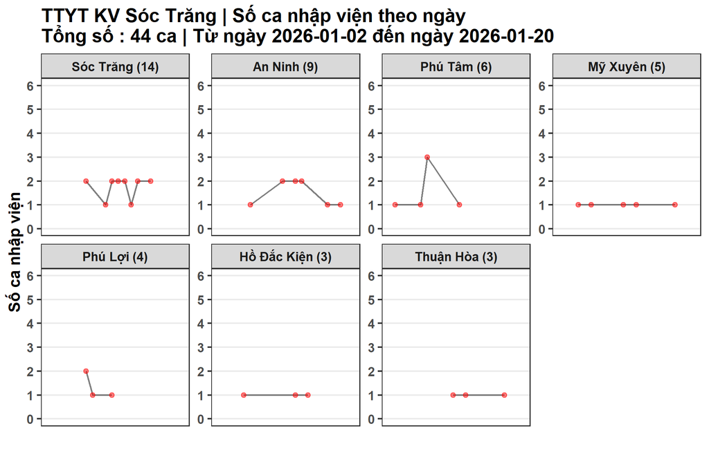

## 9.10 TTYT KV Kế Sách

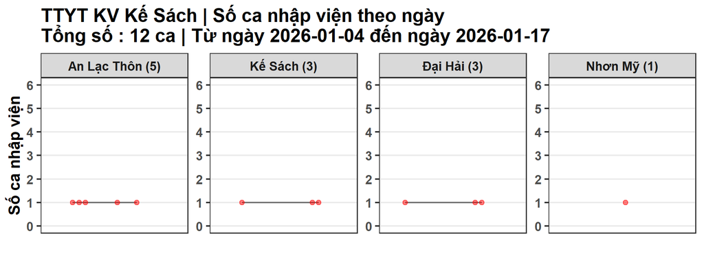

## 9.11 TTYT KV Mỹ Xuyên

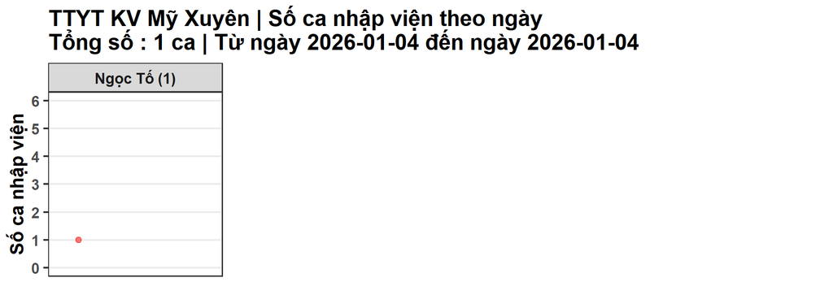

## 9.12 TTYT KV Vĩnh Thạnh

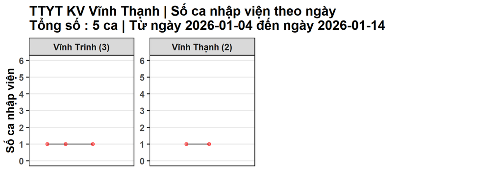

## 9.13 TTYT KV Mỹ Tú

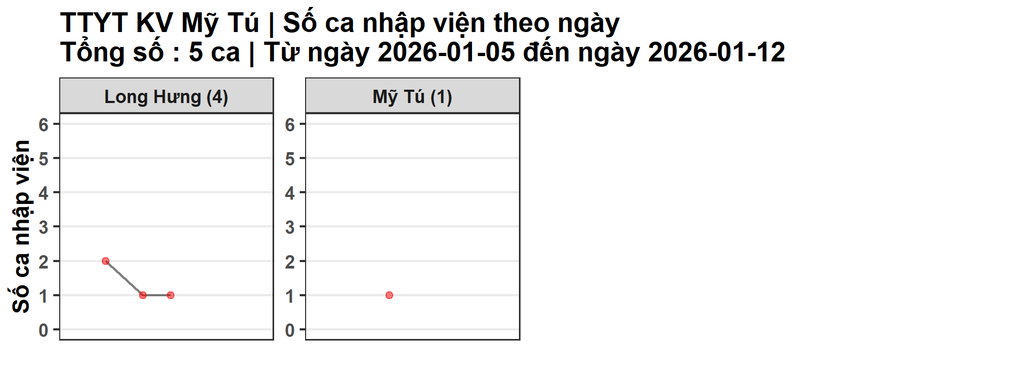

## 9.14 TTYT KV Vị Thủy

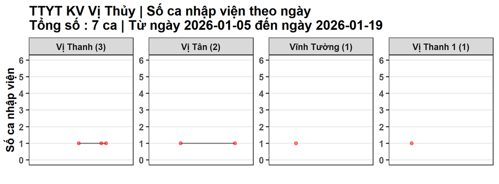

## 9.15 TTYT KV Vĩnh Châu

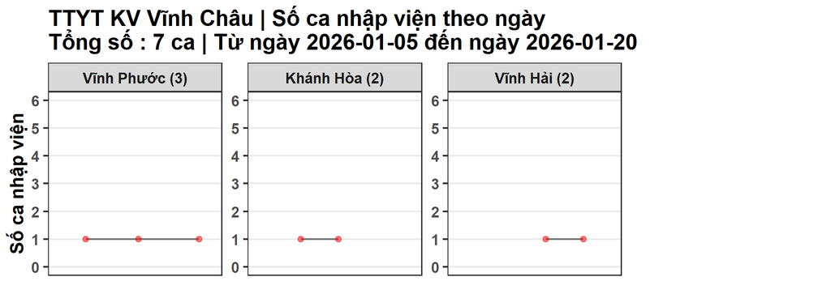

## 9.16 TTYT KV Thốt Nốt

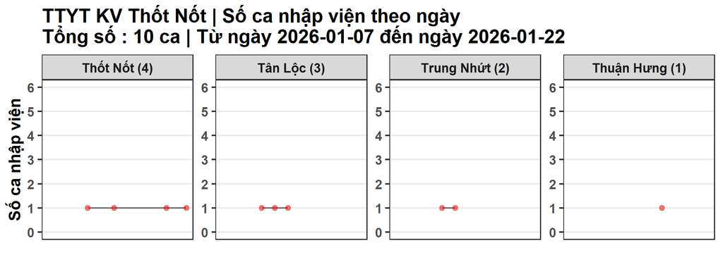

## 9.17 TTYT KV Long Mỹ

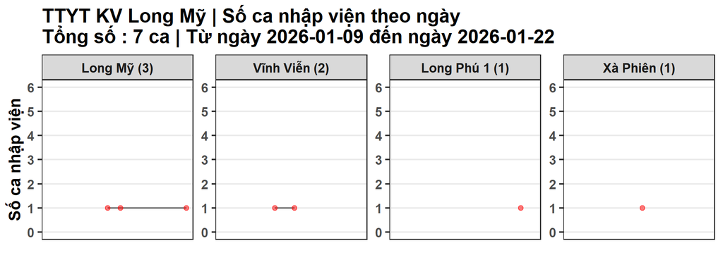

## 9.18 TTYT KV Ngã Năm

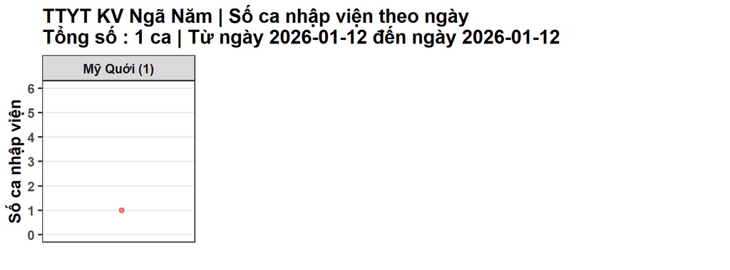

## 9.19 TTYT KV Thạnh Trị

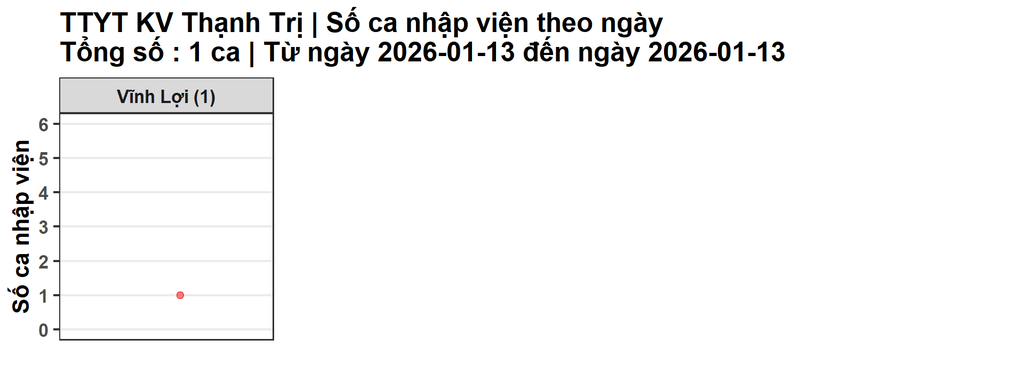

## 9.20 TTYT KV Cù Lao Dung

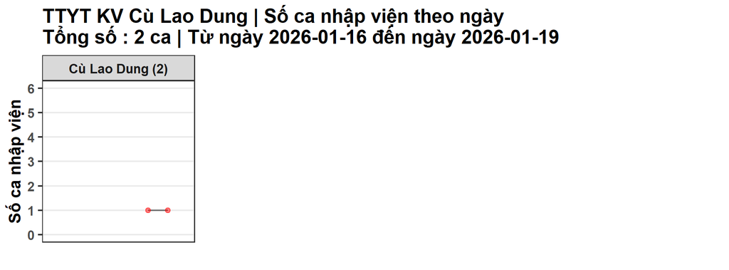

# 10 **ĐỒ THỊ THEO TUẦN**

## 10.1 TTYT KV Bình Thủy

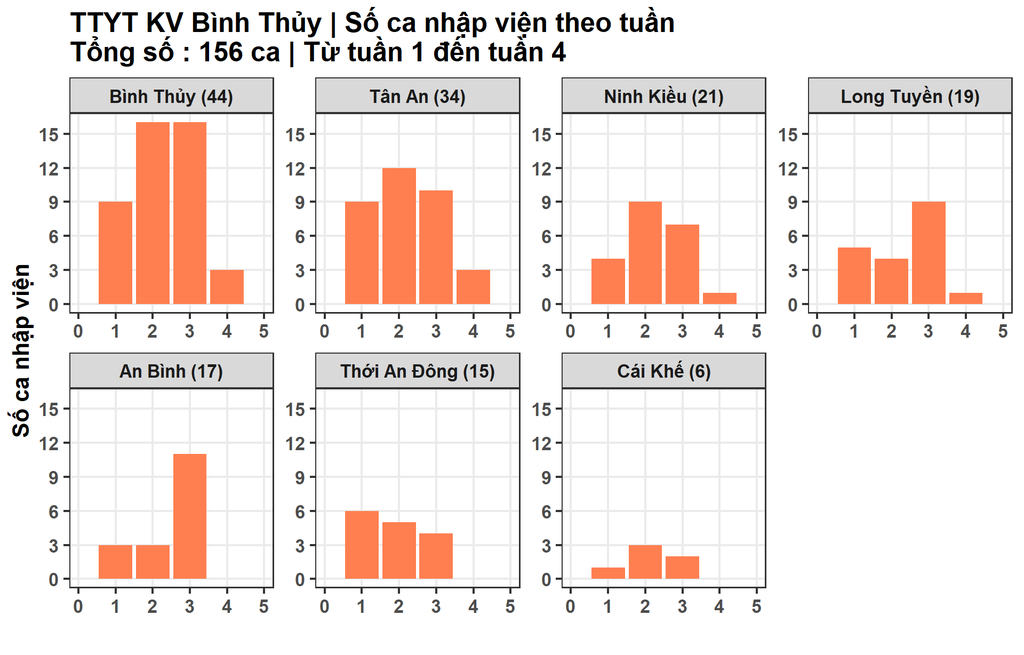

## 10.2 TTYT KV Kế Sách

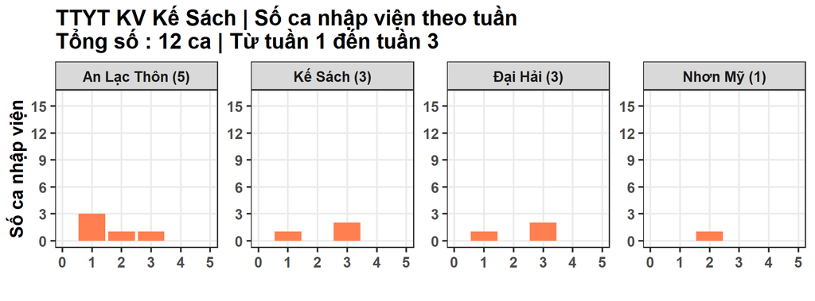

## 10.3 TTYT KV Sóc Trăng

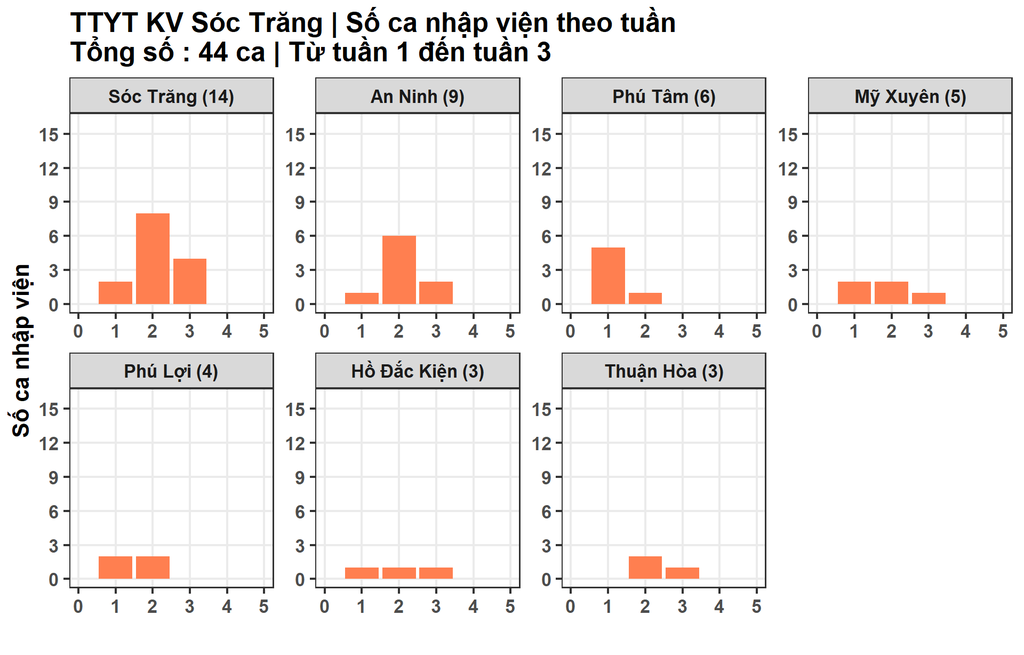

## 10.4 TTYT KV Cái Răng

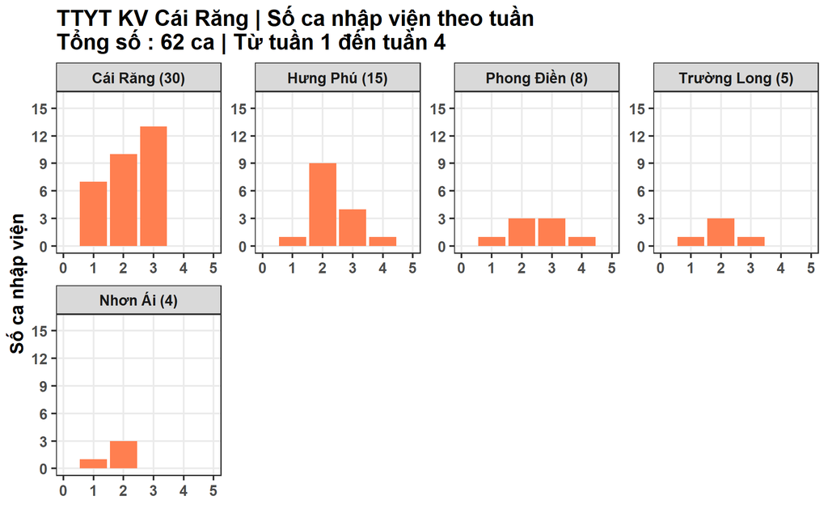

## 10.5 TTYT KV Châu Thành HG

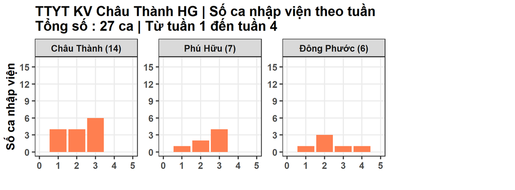

## 10.6 TTYT KV Thới Lai

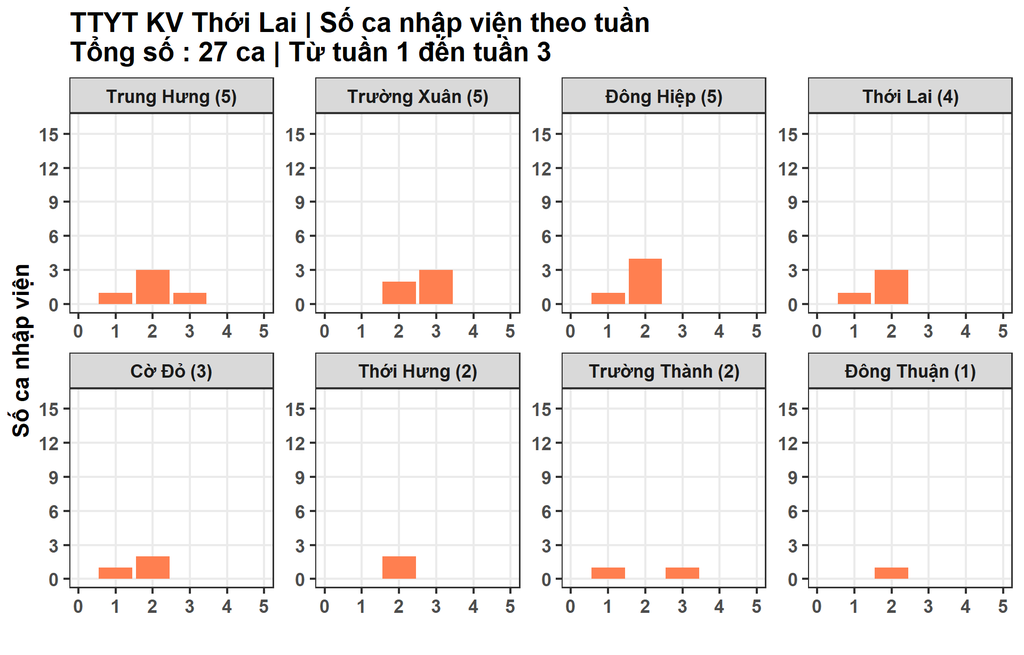

## 10.7 TTYT KV Phụng Hiệp

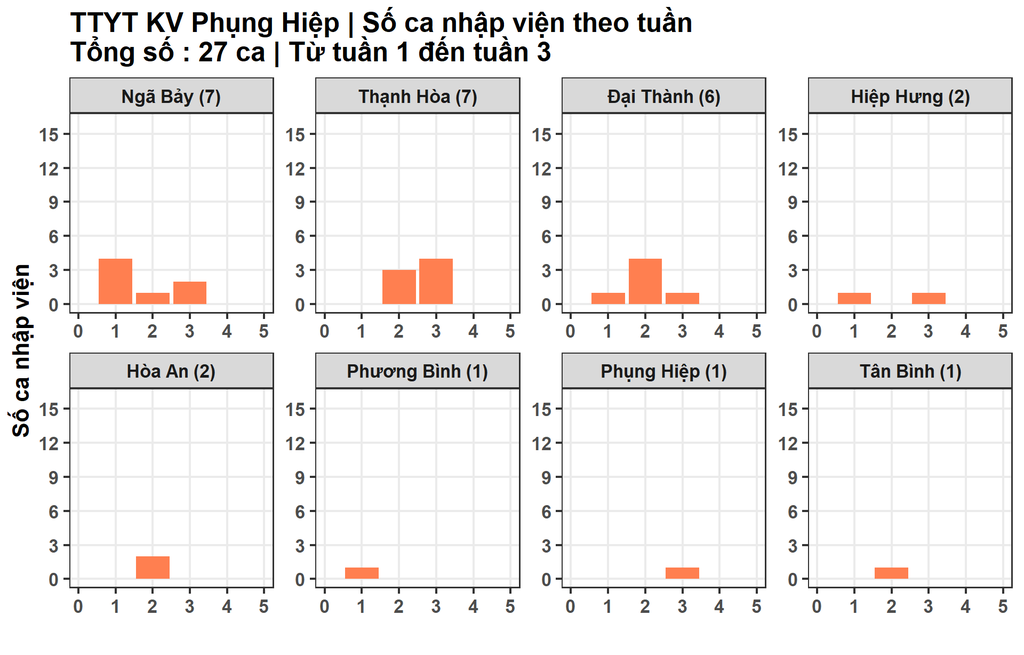

## 10.8 TTYT KV Vĩnh Châu

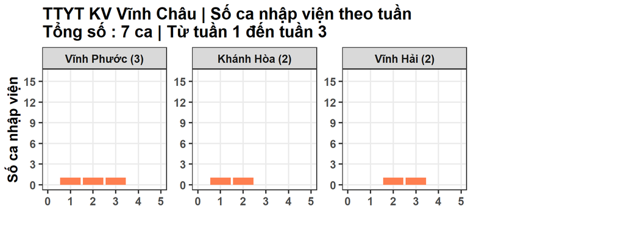